# Diabetic Retinopathy Detection: An End-to-End ML Pipeline

Clinical Feature Classification with Model Interpretability

Your Name | MS Bioinformatics, Northeastern University

May 04, 2026

# 1 Clinical Background

Diabetic retinopathy (DR) is a microvascular complication of diabetes affecting the retina. It is the **leading cause of preventable blindness in working-age adults worldwide**. Fundus photography enables non-invasive screening, but qualified ophthalmology review is resource-intensive and unavailable in many settings.

Automated classification of retinal features can triage patients, flagging those who need urgent specialist review. The central tension in this screening problem:

> **False negative (missed DR)** → delayed treatment → preventable vision loss  
> **False positive (wrong flag)** → unnecessary specialist referral → cost and patient anxiety

This asymmetry means **sensitivity is the primary metric** — we must catch nearly all DR cases, even at the cost of some false positives. This framing drives every modeling decision below.

# 2 Dataset

```r
cat("Dimensions:", nrow(dr_raw), "patients ×", ncol(dr_raw), "features\n\n")
```

```
## Dimensions: 1151 patients × 20 features
```

```r
dr_raw %>%
  summarise(
    n_patients     = n(),
    n_features     = ncol(.) - 1,
    pct_dr         = round(mean(label == "DR Present") * 100, 1),
    missing_values = sum(is.na(.))
  ) %>%
  gt() %>%
  cols_label(
    n_patients     = "Patients",
    n_features     = "Features",
    pct_dr         = "DR Positive (%)",
    missing_values = "Missing Values"
  ) %>%
  tab_header(title = "Dataset Summary") %>%
  tab_style(style = cell_text(weight = "bold"),
            locations = cells_column_labels())
```

Dataset Summary

| Patients | Features | DR Positive (%) | Missing Values |
| --- | --- | --- | --- |
| 1151 | 19 | 53.1 | 0 |

## 2.1 Feature Description

Clinical Feature Glossary

| Feature Name | Type | Clinical Interpretation |
| --- | --- | --- |
| quality | Binary | Image quality assessment — 1 = sufficient for analysis |
| pre_screening | Binary | Pre-screening flag for severe retinal abnormality |
| ma_detect_0.5–1.0 | Numeric | Microaneurysm detections at confidence levels 0.5 to 1.0 |
| exudate_1–8 | Numeric | Normalized exudate features — lipid deposits signaling vascular leakage |
| macula_od_dist | Numeric | Euclidean distance from macula to optic disc (normalized) |
| optic_disc_diam | Numeric | Optic disc diameter |
| amfm_class | Binary | AM/FM-based pre-classifier output |
| label | Target | 1 = Diabetic Retinopathy detected, 0 = no DR |

# 3 Exploratory Data Analysis

## 3.1 Class Distribution

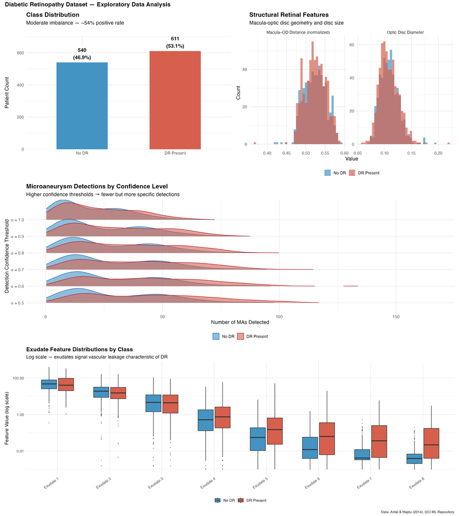

```r
knitr::include_graphics("../outputs/figures/eda_overview.png")
```

The dataset shows **moderate class imbalance** (~54% positive). While this is not extreme, it is enough to distort accuracy-based metrics and warrants SMOTE oversampling during training.

## 3.2 Feature Correlations

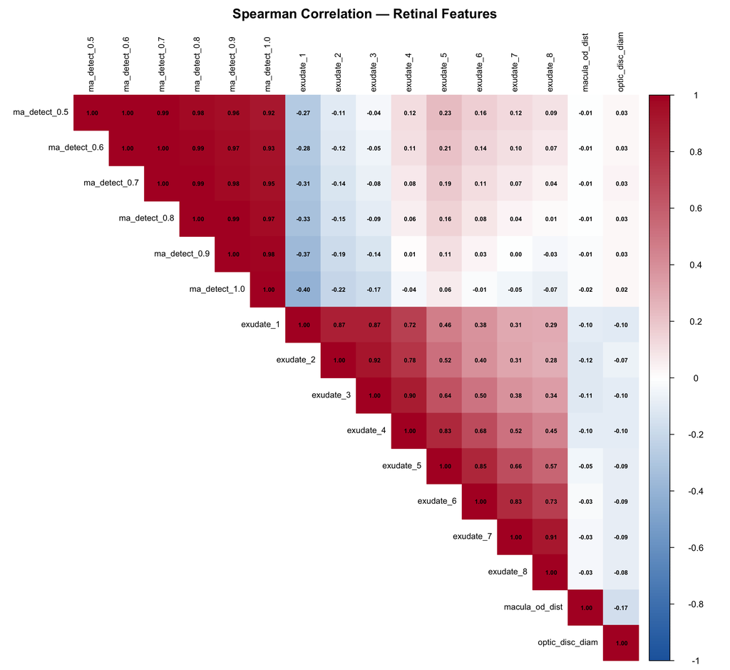

```r
knitr::include_graphics("../outputs/figures/eda_correlation_heatmap.png")
```

**Key observations:** - MA detection features at adjacent confidence levels are highly correlated (expected — a lesion detected at 0.7 confidence is almost always detected at 0.5) - Exudate features show moderate inter-correlation - Macula distance and optic disc diameter are largely independent of other features - These correlations motivate **regularization** in logistic regression and are handled naturally by tree-based ensembles

# 4 Methods

## 4.1 Train/Test Split & Cross-Validation

```r
tibble(
  Split       = c("Training", "Test"),
  N           = c(nrow(dr_train), nrow(dr_test)),
  `DR %`      = c(
    round(mean(dr_train$label == "DR Present") * 100, 1),
    round(mean(dr_test$label  == "DR Present") * 100, 1)
  )
) %>%
  gt() %>%
  tab_header(title = "Stratified 80/20 Split") %>%
  tab_style(style = cell_text(weight = "bold"),
            locations = cells_column_labels())
```

Stratified 80/20 Split

| Split | N | DR % |
| --- | --- | --- |
| Training | 920 | 53.0 |
| Test | 231 | 53.2 |

**5-fold stratified cross-validation** was used for hyperparameter tuning on the training set. SMOTE was applied *inside each fold* during training — a critical step to prevent synthetic sample leakage into validation sets.

## 4.2 Preprocessing Pipeline

```r
dr_recipe
```

[output not shown]

## 4.3 Models

| Model | Hyperparameters Tuned | Rationale |
| --- | --- | --- |
| L2 Logistic Regression | Penalty λ | Clinical baseline; interpretable log-odds coefficients |
| Random Forest | mtry, min_n | Strong ensemble; native importance; handles correlated features |
| XGBoost | trees, depth, learning rate, subsampling, mtry, loss reduction | State-of-the-art tabular performance |
| SVM (RBF) | cost, σ | Effective on smaller clinical datasets; non-linear boundaries |

# 5 Results

## 5.1 Cross-Validation Performance

```r
cv_results_tbl <- cv_results %>%
  pivot_wider(
    names_from  = .metric,
    values_from = c(mean, std_err),
    values_fn   = list(mean = ~ mean(.x, na.rm = TRUE),
                       std_err = ~ mean(.x, na.rm = TRUE))
  ) %>%
  select(model, mean_roc_auc, mean_sensitivity, mean_specificity) %>%
  mutate(across(starts_with("mean_"), as.numeric)) %>%
  mutate(across(starts_with("mean_"), ~ round(.x, 4)))

cv_results_tbl %>%
  gt() %>%
  tab_header(
    title    = "Cross-Validation Performance",
    subtitle = "Best hyperparameters per model | 5-fold stratified CV on training set"
  ) %>%
  cols_label(
    model            = "Model",
    mean_roc_auc     = "AUROC",
    mean_sensitivity = "Sensitivity",
    mean_specificity = "Specificity"
  ) %>%
  fmt_number(columns = starts_with("mean_"), decimals = 4) %>%
  tab_style(
    style = cell_fill(color = "#d4edda"),
    locations = cells_body(
      rows = mean_roc_auc == max(mean_roc_auc, na.rm = TRUE)
    )
  ) %>%
  tab_style(
    style = cell_text(weight = "bold"),
    locations = cells_column_labels()
  )
```

Cross-Validation Performance

Best hyperparameters per model | 5-fold stratified CV on training set

| Model | AUROC | Sensitivity | Specificity |
| --- | --- | --- | --- |
| Logistic Regression | 0.7481 | 0.7384 | 0.6557 |
| Random Forest | 0.7407 | 0.7015 | 0.6638 |
| XGBoost | 0.7858 | 0.7711 | 0.8033 |
| SVM | 0.7996 | 0.8171 | 1.0000 |

## 5.2 ROC Curves

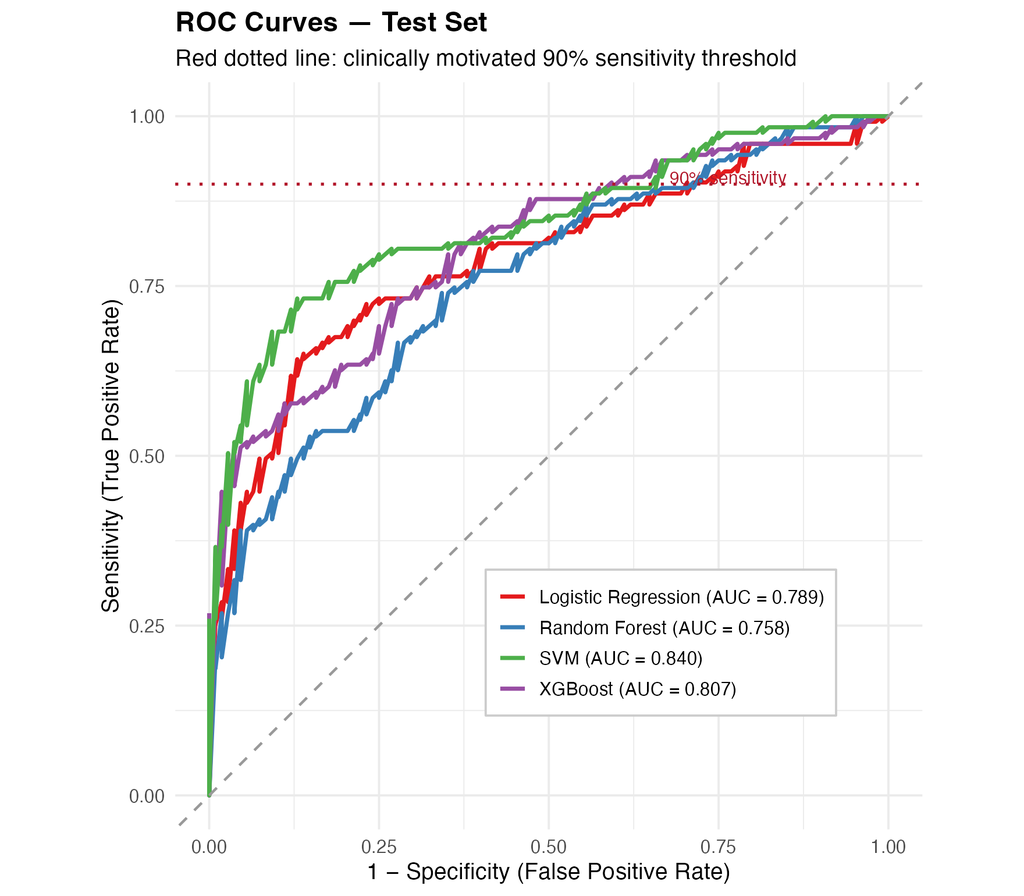

```r
knitr::include_graphics("../outputs/figures/eval_roc_curves.png")
```

## 5.3 Precision-Recall Curves

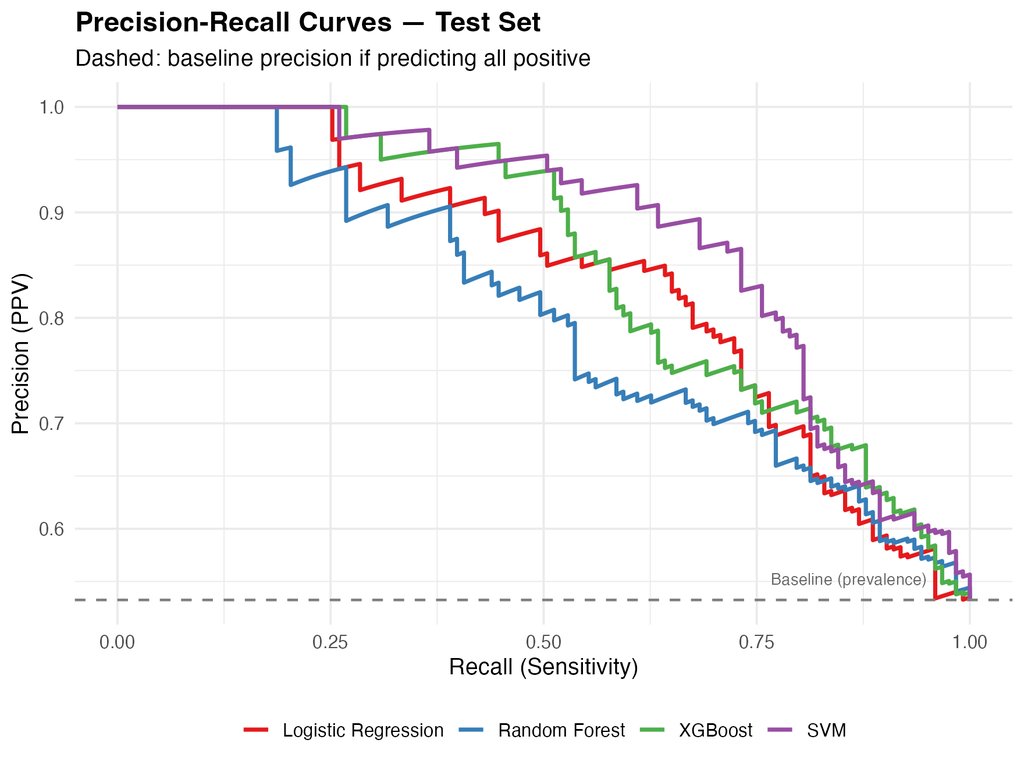

```r
knitr::include_graphics("../outputs/figures/eval_pr_curves.png")
```

Precision-Recall curves are more informative than ROC in screening settings because they directly show the **tradeoff between catching cases (recall/sensitivity) and avoiding false referrals (precision/PPV)**.

## 5.4 Confusion Matrices at 90% Sensitivity Threshold

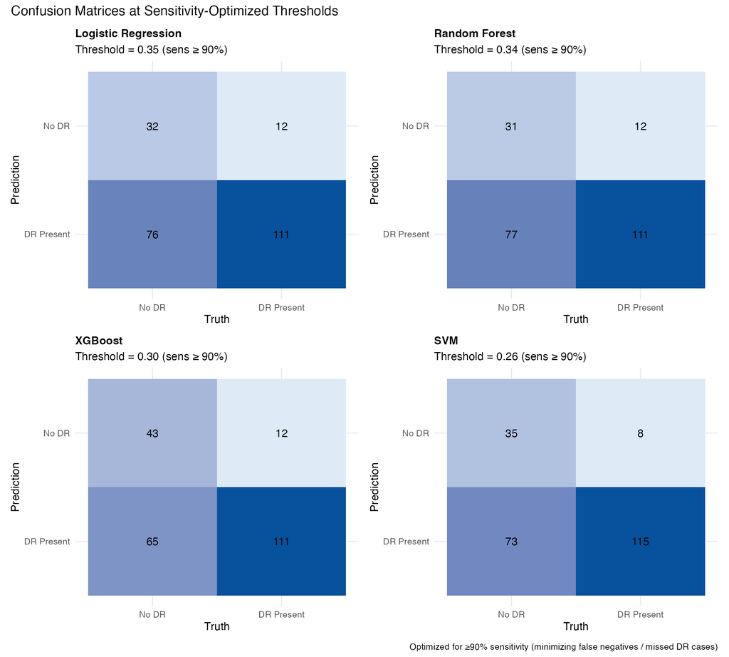

```r
knitr::include_graphics("../outputs/figures/eval_confusion_matrices.png")
```

In a clinical screening workflow, we would typically **lower the classification threshold** from 0.5 to whatever value achieves ≥90% sensitivity, accepting more false positives in exchange for catching nearly all true DR cases.

## 5.5 Threshold Tradeoff Analysis

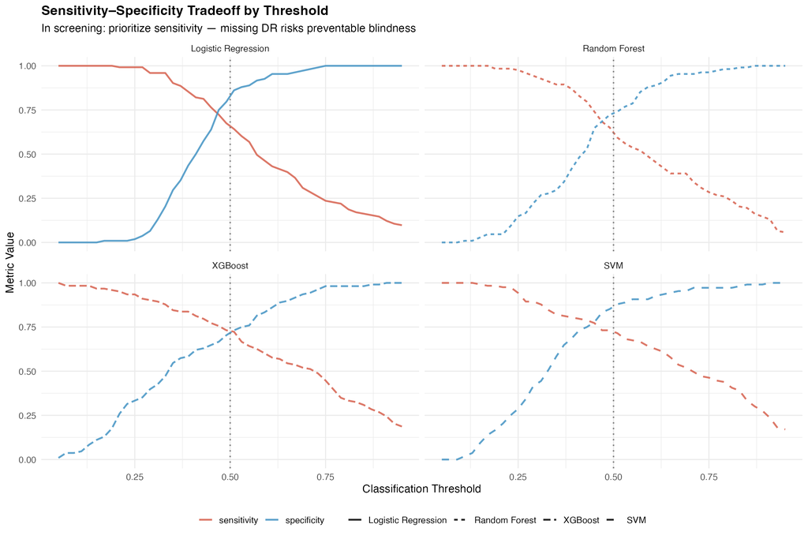

```r
knitr::include_graphics("../outputs/figures/eval_threshold_tradeoff.png")
```

## 5.6 Calibration (XGBoost)

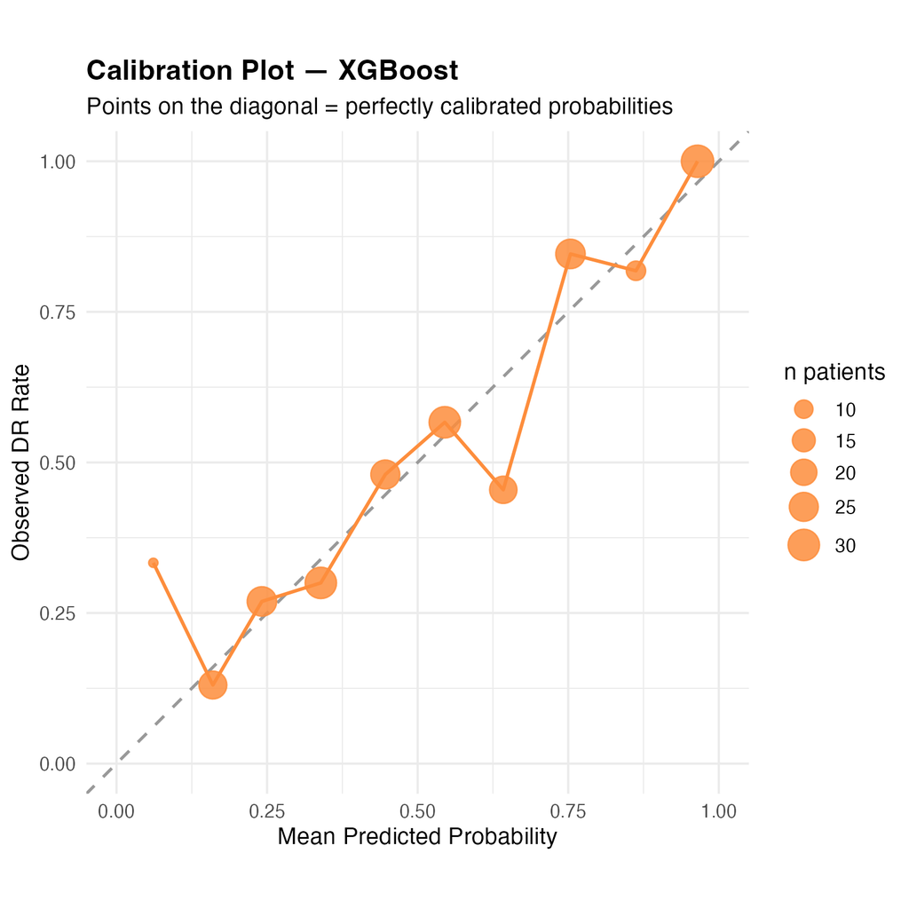

```r
knitr::include_graphics("../outputs/figures/eval_calibration.png")
```

Calibration assesses whether predicted probabilities are reliable. A perfectly calibrated model would have all points on the diagonal. Well-calibrated probability estimates are essential for **clinical risk stratification** — a patient with 85% predicted DR probability should genuinely have ~85% prevalence of DR.

## 5.7 Final Test Set Results

```r
test_results %>%
  select(model, AUROC, Sensitivity_default = Sensitivity,
         Specificity_default = Specificity,
         threshold_opt = threshold, sensitivity_opt = sensitivity,
         specificity_opt = specificity) %>%
  gt() %>%
  tab_header(
    title    = "Test Set Performance",
    subtitle = "Default threshold (0.5) vs. sensitivity-optimized threshold (≥90% sens)"
  ) %>%
  tab_spanner(
    label   = "Default Threshold (0.5)",
    columns = c(AUROC, Sensitivity_default, Specificity_default)
  ) %>%
  tab_spanner(
    label   = "Optimized Threshold (≥90% sensitivity)",
    columns = c(threshold_opt, sensitivity_opt, specificity_opt)
  ) %>%
  fmt_number(columns = where(is.numeric), decimals = 4) %>%
  tab_style(
    style     = cell_fill(color = "#d4edda"),
    locations = cells_body(rows = AUROC == max(AUROC))
  ) %>%
  tab_style(style = cell_text(weight = "bold"),
            locations = cells_column_labels())
```

Test Set Performance

Default threshold (0.5) vs. sensitivity-optimized threshold (≥90% sens)

| model | Default Threshold (0.5) AUROC | Default Threshold (0.5) Sensitivity_default | Default Threshold (0.5) Specificity_default | Optimized Threshold (≥90% sensitivity) threshold_opt | Optimized Threshold (≥90% sensitivity) sensitivity_opt | Optimized Threshold (≥90% sensitivity) specificity_opt |
| --- | --- | --- | --- | --- | --- | --- |
| Logistic Regression | 0.7889 | 0.6585 | 0.8333 | 0.3500 | 0.9024 | 0.2963 |
| Random Forest | 0.7580 | 0.6098 | 0.7315 | 0.3400 | 0.9024 | 0.2870 |
| XGBoost | 0.8067 | 0.7317 | 0.7130 | 0.3000 | 0.9024 | 0.3981 |
| SVM | 0.8403 | 0.6667 | 0.9074 | 0.2600 | 0.9350 | 0.3241 |

# 6 Model Interpretability

## 6.1 Variable Importance: RF vs XGBoost

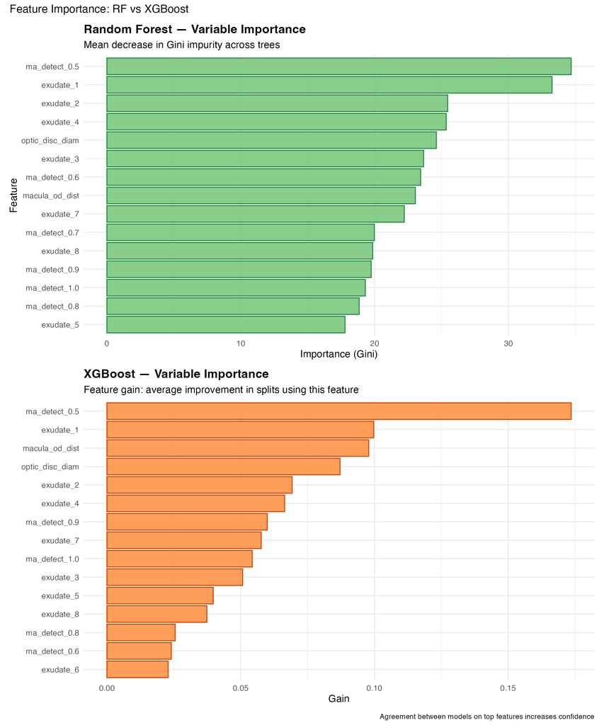

```r
knitr::include_graphics("../outputs/figures/interp_variable_importance.png")
```

**Agreement between models on top features increases confidence** that these features are genuinely predictive rather than artefacts of any single algorithm’s inductive bias.

## 6.2 SHAP Values (XGBoost — Global)

[figure not shown]

```r
knitr::include_graphics("../outputs/figures/interp_shap_summary.png")
```

## 6.3 SHAP Dependence Plots

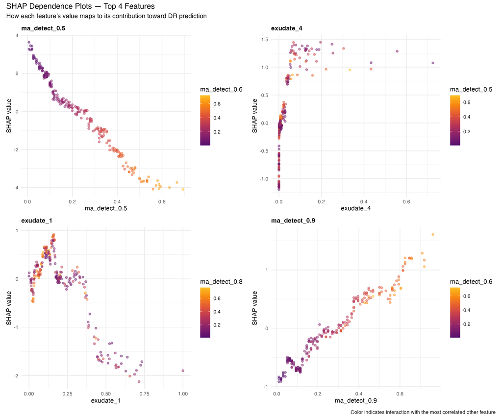

```r
knitr::include_graphics("../outputs/figures/interp_shap_dependence.png")
```

## 6.4 SHAP for Logistic Regression

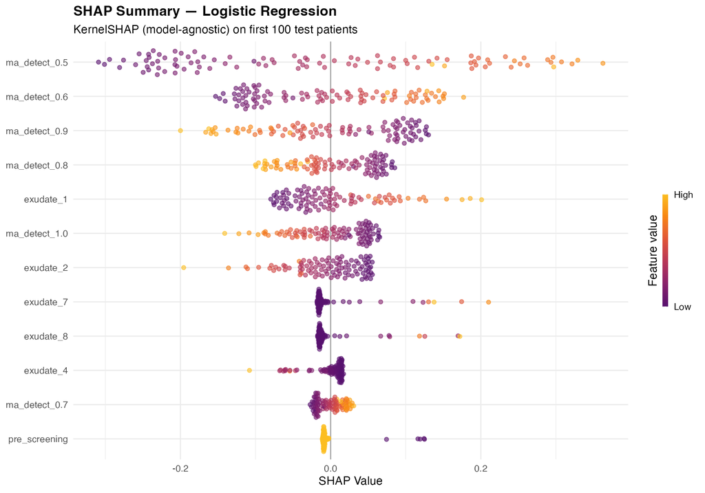

```r
knitr::include_graphics("../outputs/figures/interp_shap_lr.png")
```

## 6.5 Individual Case Narratives

### 6.5.1 True Positive — DR Correctly Identified

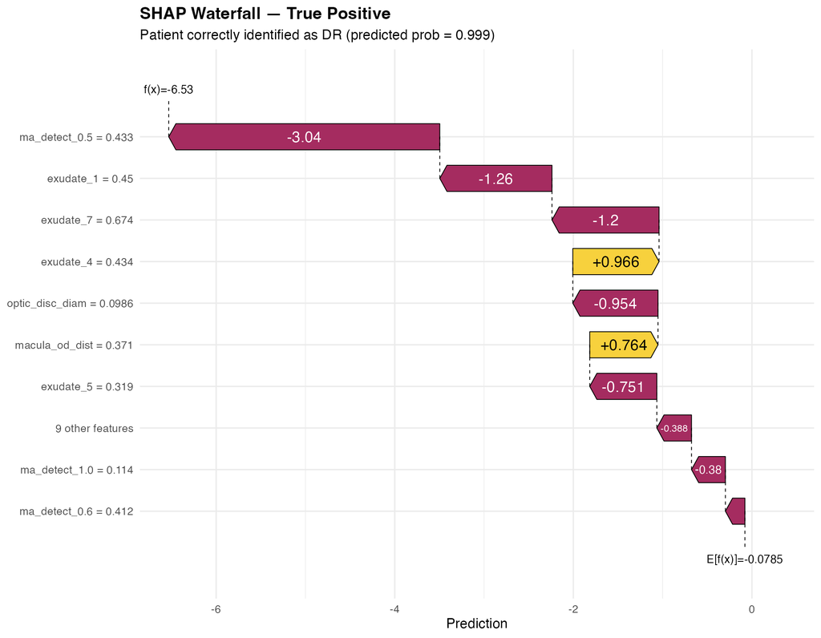

```r
knitr::include_graphics("../outputs/figures/interp_waterfall_true_positive.png")
```

### 6.5.2 False Negative — Missed DR Case

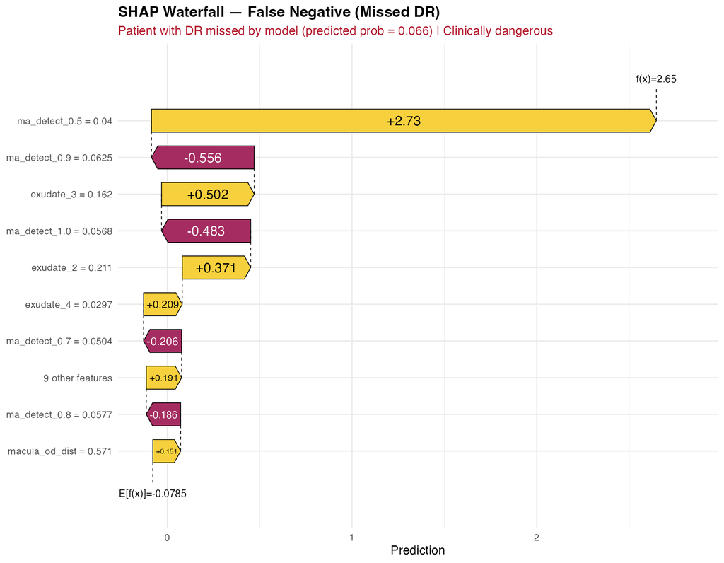

```r
if (file.exists("../outputs/figures/interp_waterfall_false_negative.png")) {
  knitr::include_graphics("../outputs/figures/interp_waterfall_false_negative.png")
}
```

This is the clinically dangerous case — a patient with DR that the model classified as negative. The waterfall reveals *which features drove the wrong prediction*, providing actionable feedback for model improvement or clinical rule addition.

# 7 Clinical Interpretation

## 7.2 Sensitivity vs. Specificity — The Clinical Tradeoff

[output not shown]

The right threshold depends on **healthcare system capacity**: a high-volume low-resource setting may prefer aggressive sensitivity; a specialist-scarce setting needs careful threshold calibration to avoid overwhelming ophthalmology.

# 8 Limitations

1. **Fixed feature extraction pipeline**: Features were extracted by a specific image analysis system. The model’s performance depends on the quality of upstream feature extraction and may not generalize to different fundus camera systems.
2. **Single-site data**: Images collected at one center (Debrecen, Hungary). Ethnic diversity, lighting conditions, and camera hardware vary across sites — external validation is essential before clinical deployment.
3. **No temporal modeling**: DR is progressive. A single-timepoint classifier cannot capture rate of change — a key clinical signal. Longitudinal modeling would improve risk stratification.
4. **ARFF normalization**: The 8 exudate features are pre-normalized, masking absolute scale information that may be clinically meaningful.
5. **Sample size**: 1,151 patients is small for a deep learning approach. This dataset is appropriate for classical ML but motivates collection of larger cohorts for future deep learning work.

To reproduce this analysis:

```r
# 1. Clone repo and download data
# 2. renv::restore()
# 3. source("R/00_run_all.R")
# 4. rmarkdown::render("reports/analysis_report.Rmd", output_dir = "outputs/")
```

*This project was developed as a portfolio demonstration of clinical ML methodology, with relevance to AI-assisted diagnostics and genomic variant classification tasks.*